# LAB06 : Conteneurisation d’une pile LAMP (Linux Apache – PHP – MySQL)

## 3.3. Déploiement de l'application

1. Placez vous au niveau du répertoire qui contient le fichier **docker-compose.yml**.
2. Ensuite lancez la commande suivante pour exécuter les services du **docker-compose.yml** :

```python
docker-compose up -d
```

```python
[+] Running 2/2
 ⠿ Container mysql_container  Started                                                                                            1.3s
 ⠿ Container myweb_container  Started
```

3. Vérifiez le démarrage des conteneurs.

```python
docker ps
```

```python
## Résultat
CONTAINER ID   IMAGE      COMMAND                  CREATED          STATUS          PORTS                                   NAMES
faec516ccf63   myweb_app   "docker-php-entrypoi…"   18 seconds ago   Up 11 seconds   0.0.0.0:8080->80/tcp, :::8080->80/tcp   myweb_container
57a2ed3153eb   mysql_db   "docker-entrypoint.s…"   19 seconds ago   Up 14 seconds   3306/tcp, 33060/tcp                     mysql_container
```

4. Il est possible de lister seulement de conteneurs issus de docker-compose.

```python
docker-compose ps
```

5. Vérifiez l'accès à l'application à l’aide de votre navigateur Web : http://localhost:8080.

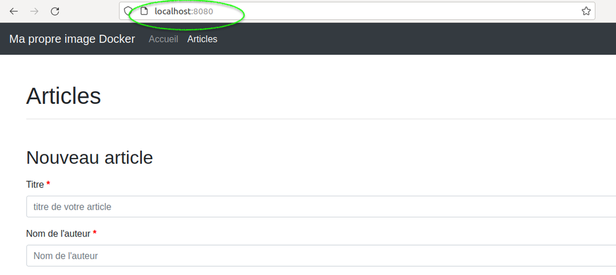

6. Ajoutez l'article suivant :
   - Titre : Lord of the Flies
   - Auteur : William Golding
   - Description : Lord of the Flies is a 1954 novel by Nobel Prize-winning British author William Golding.

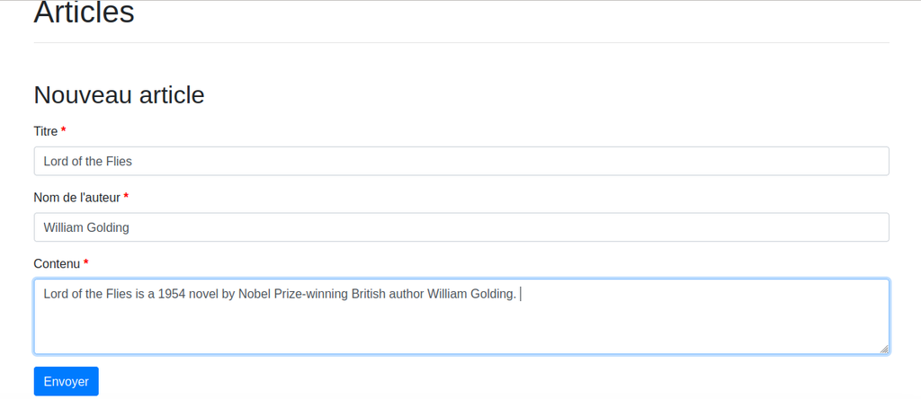

## 3.4. Gestion de la base de données

### 3.4.1. Gestion de la base de données : accès conteneur MySQL

1. Pour faire accès à la base de données de l'application, on va utiliser en premier temps la commande "docker exec"

```python
docker exec -it mysql_container /bin/bash
```

2. A l'intérieur du conteneur, exécutez la ligne de commande suivante :

```python
mysql -uroot -p
```

```python
### Résultat
Enter password:
Welcome to the MySQL monitor.  Commands end with ; or \g.
Your MySQL connection id is 104
Server version: 5.7.36 MySQL Community Server (GPL)

Copyright (c) 2000, 2021, Oracle and/or its affiliates.

Oracle is a registered trademark of Oracle Corporation and/or its
affiliates. Other names may be trademarks of their respective
owners.

Type 'help;' or '\h' for help. Type '\c' to clear the current input statement.

mysql>
```

3. Pour voir la liste des bases de données, tapez :

```python
mysql> SHOW DATABSASES;
```

```python
### Résultat
+--------------------+
| Database           |
+--------------------+
| information_schema |
| mysql              |
| performance_schema |
| sys                |
| test               |
+--------------------+
5 rows in set (0.00 sec)
```

4. Pour utiliser la base de données "test", tapez :

```python
mysql> USE test;
```

5. Pour afficher le contenu de la table "articles", tapez :

```python
mysql> SELECT * FROM articles;
```

```python
### Résultat
+----+-------------------+-----------------+---------------------+-------------------------------------------------------------------------------------------+
| id | title             | author          | date                | content                                                                                   |
+----+-------------------+-----------------+---------------------+-------------------------------------------------------------------------------------------+
|  5 | Lord of the Flies | William Golding | 2021-11-08 23:44:04 | Lord of the Flies is a 1954 novel by Nobel Prize-winning British author William Golding.  |
+----+-------------------+-----------------+---------------------+-------------------------------------------------------------------------------------------+
1 row in set (0.00 sec)
```

### 3.4.2. Gestion de la base de données à l'aide de l'application web phpMyAdmin

L'outil phpMyAdmin offre une interface web simple pour gérer une base de données MySQL sur un serveur PHP.

[figure not shown]

- **On va utiliser un conteneur phpMyAdmin et le connecter à la base de données MySQL.**
1. **Démarrez le conteneur "pma_container" à partir de l'image officielle "phpmyadmin" accesible à : https://hub.docker.com/_/phpmyadmin avec les options suivantes :**
   - Mode d'exécution en arrière plan : -d
   - Nom conteneur : --name pma_container
   - Port mapping : -p 8081:80
   - Variable d'environnement : -e PMA_HOST= mysql_container
   - Réseau : ???????

**Solution**

```python
docker run -d --name pma_container -p 8081:80 -e PMA_HOST=mysql_container --network=sources_default  phpmyadmin
```

2. Après ajout de l'option nécessaire, testez l'accès à l'interface phpMyAdmin à travers le lien : http://localhost:8081/

[figure not shown]

[figure not shown]

**Solution**

```python
version: '3.7'

services:
    db:
     image: mysql_db
     container_name: mysql_container
     restart: always
     volumes:
      - /home/$USER/db-volume:/var/lib/mysql
    web:
     image: myweb_app
     container_name: myweb_container
     restart: always
     ports:
      - 8080:80
     depends_on:
      - db
    pma:
     image: phpmyadmin
     container_name: pma_container
     restart: always
     ports:
      - 8081:80
     environment:
      - PMA_HOST:db
     links:
      - db
```